# Fragilidad bancaria, GaR y spread soberano — panel Bloomberg

EDA y batería de regresiones del Capítulo 2 (reproducción en R)

Mauricio Valenzuela Corvalán

10 de septiembre de 2026

# 1 Qué es este documento

Réplica en R, autocontenida y reproducible, de la evidencia empírica del Capítulo 2 de la tesis *“Fragilidad bancaria, riesgo de cola del crecimiento y spread soberano en economías emergentes”*: un EDA rápido del panel único anclado en Bloomberg y la batería de regresiones que es su esqueleto (Tabla 2.3 de la tesis). El pipeline canónico está en Python (`1_Codigo/Panel/bbg/p1..p8`); este `.Rmd` es la versión para tener a mano — o correr en vivo— si en la defensa piden ver el código o probar algo distinto.

Requiere los paquetes `plm`, `lmtest` y `knitr` (`install.packages(c("plm", "lmtest", "knitr"))`), y que `Panel_bloomberg.csv` esté en la misma carpeta que este archivo.

# 2 Los datos

```r
panel <- read.csv("Panel_bloomberg.csv", stringsAsFactors = FALSE)
panel$GaR_pp <- panel$GaR * 100

# Muestra de estimación: EMBI + JLoss + GaR disponibles simultáneamente
est <- subset(panel, !is.na(EMBI_bps) & !is.na(JLoss) & !is.na(GaR))
est$country <- factor(est$country)

cat(sprintf("Panel completo (roster): %d filas, %d economías, %s a %s\n",
            nrow(panel), length(unique(panel$country)), min(panel$quarter), max(panel$quarter)))
```

```
## Panel completo (roster): 1488 filas, 17 economías, 2004Q1 a 2026Q3
```

```r
cat(sprintf("Muestra de estimación   : %d filas, %d países\n",
            nrow(est), length(unique(est$country))))
```

```
## Muestra de estimación   : 721 filas, 13 países
```

La variable dependiente principal es el **EMBI Global Diversified** (J.P. Morgan), siguiendo a Chari et al. (2024); el CDS soberano a 5 años de Bloomberg queda como serie de robustez. `JLoss` es la métrica semiparamétrica de pérdida conjunta esperada del sistema bancario (Merton/KMV + punto de silla, 113 bancos); `GaR` es el cuantil 5 % de la distribución condicional del crecimiento (regresión cuantílica de panel, marco CEMLA). Corea del Sur, Bulgaria y Hungría quedan fuera del panel: en las tres, `JLoss` no es una medida sistémica válida a nivel país (número de bancos cotizados insuficiente).

## 2.1 Cobertura por país

```r
cobertura <- do.call(rbind, lapply(split(est, est$country), function(g) {
  data.frame(país = unique(g$country), n_trim = nrow(g),
             desde = min(g$quarter), hasta = max(g$quarter),
             con_CDS = sum(!is.na(g$CDS_bps)),
             JLoss_mediana = round(median(g$JLoss), 2),
             JLoss_máx = round(max(g$JLoss), 1))
}))
cobertura <- cobertura[order(-cobertura$n_trim), ]
kable(cobertura, row.names = FALSE)
```

| país | n_trim | desde | hasta | con_CDS | JLoss_mediana | JLoss_máx |
| --- | --- | --- | --- | --- | --- | --- |
| poland | 89 | 2004Q1 | 2026Q1 | 14 | 2.64 | 15.0 |
| china | 79 | 2006Q3 | 2026Q1 | 79 | 3.79 | 29.0 |
| mexico | 77 | 2006Q4 | 2025Q4 | 77 | 2.38 | 13.9 |
| brazil | 75 | 2007Q3 | 2026Q1 | 75 | 4.01 | 15.5 |
| chile | 75 | 2007Q3 | 2026Q1 | 75 | 2.21 | 11.6 |
| colombia | 70 | 2008Q4 | 2026Q1 | 70 | 2.36 | 16.7 |
| peru | 66 | 2009Q4 | 2026Q1 | 66 | 2.18 | 8.7 |
| turkey | 63 | 2010Q3 | 2026Q1 | 63 | 6.04 | 28.0 |
| india | 54 | 2012Q4 | 2026Q1 | 0 | 7.45 | 23.2 |
| malaysia | 40 | 2016Q2 | 2026Q1 | 40 | 2.19 | 5.9 |
| indonesia | 11 | 2023Q3 | 2026Q1 | 11 | 2.27 | 3.7 |
| philippines | 11 | 2023Q3 | 2026Q1 | 11 | 2.86 | 4.3 |
| southafrica | 11 | 2023Q3 | 2026Q1 | 11 | 2.38 | 3.9 |

## 2.2 Estadística descriptiva

```r
vars_desc <- c("EMBI_bps", "CDS_bps", "JLoss", "GaR_pp",
               "debt_gdp", "fisc_bal", "res_gdp", "ca_gdp", "infl_yoy", "reer")
desc <- do.call(rbind, lapply(vars_desc, function(v) {
  x <- est[[v]]
  data.frame(variable = v, media = mean(x, na.rm = TRUE), sd = sd(x, na.rm = TRUE),
             mín = min(x, na.rm = TRUE), máx = max(x, na.rm = TRUE), n_NA = sum(is.na(x)))
}))
kable(desc, digits = 2, row.names = FALSE)
```

| variable | media | sd | mín | máx | n_NA |
| --- | --- | --- | --- | --- | --- |
| EMBI_bps | 197.21 | 105.48 | 15.00 | 660.59 | 0 |
| CDS_bps | 137.05 | 97.74 | 11.13 | 780.02 | 129 |
| JLoss | 4.79 | 4.59 | 1.43 | 28.97 | 0 |
| GaR_pp | 1.51 | 3.77 | -17.67 | 13.28 | 0 |
| debt_gdp | 50.75 | 21.16 | 6.50 | 103.05 | 78 |
| fisc_bal | -3.78 | 2.64 | -13.20 | 2.77 | 78 |
| res_gdp | 20.07 | 8.14 | 9.52 | 47.27 | 86 |
| ca_gdp | -1.60 | 2.94 | -8.85 | 9.80 | 94 |
| infl_yoy | 5.77 | 9.11 | -1.89 | 83.45 | 96 |
| reer | 108.85 | 19.48 | 68.77 | 181.69 | 78 |

## 2.3 Distribuciones

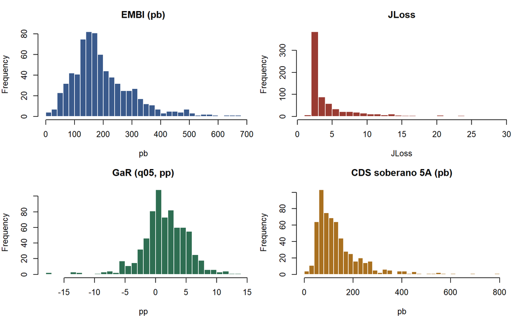

```r
par(mfrow = c(2, 2), mar = c(4, 4, 3, 1))
hist(est$EMBI_bps, breaks = 30, col = "#3A5A8C", border = "white", main = "EMBI (pb)", xlab = "pb")
hist(est$JLoss, breaks = 30, col = "#9A3B32", border = "white", main = "JLoss", xlab = "JLoss")
hist(est$GaR_pp, breaks = 30, col = "#2E6E52", border = "white", main = "GaR (q05, pp)", xlab = "pp")
hist(est$CDS_bps, breaks = 30, col = "#A9701F", border = "white", main = "CDS soberano 5A (pb)", xlab = "pb")
```

## 2.4 La dispersión transversal de `JLoss`

Nueve de trece países tienen una mediana de `JLoss` casi idéntica (2,2 a 2,9); Turquía, India, China y Brasil son los que aportan variación entre países. Es la razón por la que, más adelante, la identificación de la interacción descansa desproporcionadamente en un puñado de economías.

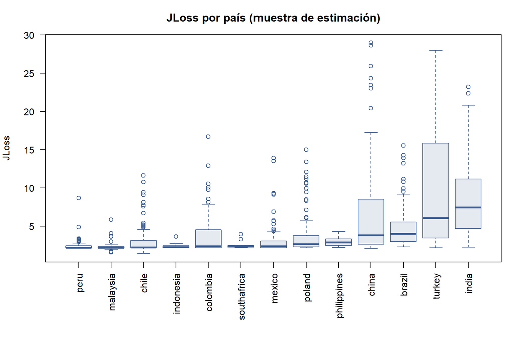

```r
ord <- names(sort(tapply(est$JLoss, est$country, median)))
par(mar = c(7, 4, 3, 1))
boxplot(JLoss ~ factor(country, levels = ord), data = est, las = 2,
        col = "#3A5A8C22", border = "#3A5A8C",
        main = "JLoss por país (muestra de estimación)", xlab = "", ylab = "JLoss")
```

## 2.5 Correlaciones, y el EMBI frente al CDS

```r
vars_cor <- c("EMBI_bps", "CDS_bps", "JLoss", "GaR_pp", "debt_gdp", "infl_yoy", "reer")
kable(round(cor(est[, vars_cor], use = "pairwise.complete.obs"), 2))
```

|  | EMBI_bps | CDS_bps | JLoss | GaR_pp | debt_gdp | infl_yoy | reer |
| --- | --- | --- | --- | --- | --- | --- | --- |
| EMBI_bps | 1.00 | 0.86 | 0.40 | -0.34 | -0.04 | 0.50 | 0.10 |
| CDS_bps | 0.86 | 1.00 | 0.51 | -0.23 | -0.02 | 0.72 | 0.07 |
| JLoss | 0.40 | 0.51 | 1.00 | -0.13 | 0.22 | 0.38 | -0.22 |
| GaR_pp | -0.34 | -0.23 | -0.13 | 1.00 | -0.17 | -0.08 | -0.03 |
| debt_gdp | -0.04 | -0.02 | 0.22 | -0.17 | 1.00 | -0.18 | -0.01 |
| infl_yoy | 0.50 | 0.72 | 0.38 | -0.08 | -0.18 | 1.00 | -0.09 |
| reer | 0.10 | 0.07 | -0.22 | -0.03 | -0.01 | -0.09 | 1.00 |

```r
comun <- subset(est, !is.na(EMBI_bps) & !is.na(CDS_bps))
cat(sprintf("EMBI vs CDS, submuestra donde ambos existen: N=%d, correlación=%.2f\n",
            nrow(comun), cor(comun$EMBI_bps, comun$CDS_bps)))
```

```
## EMBI vs CDS, submuestra donde ambos existen: N=592, correlación=0.86
```

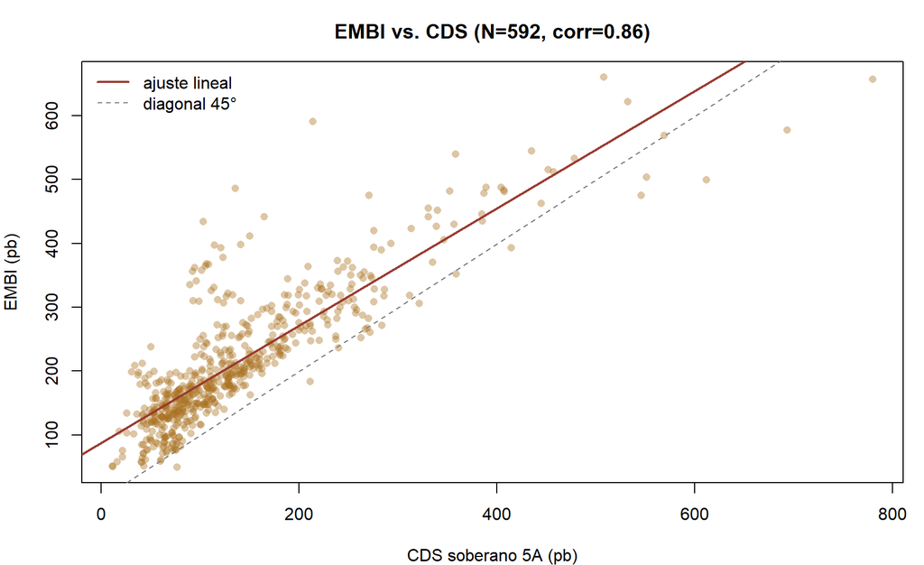

```r
par(mar = c(4, 4, 3, 1))
plot(comun$CDS_bps, comun$EMBI_bps, pch = 16, col = adjustcolor("#A9701F", 0.4),
     xlab = "CDS soberano 5A (pb)", ylab = "EMBI (pb)",
     main = sprintf("EMBI vs. CDS (N=%d, corr=%.2f)", nrow(comun), cor(comun$EMBI_bps, comun$CDS_bps)))
abline(0, 1, lty = 2, col = "grey50")
abline(lm(EMBI_bps ~ CDS_bps, comun), col = "#9A3B32", lwd = 2)
legend("topleft", legend = c("ajuste lineal", "diagonal 45°"),
       col = c("#9A3B32", "grey50"), lty = c(1, 2), lwd = c(2, 1), bty = "n")
```

# 3 La batería de regresiones (esqueleto del Capítulo 2)

Cuatro modelos anidados (`JLoss` solo; `GaR` solo; ambos; ambos más la interacción `JLoss`$\times$`GaR`) $\times$ tres estructuras de efectos fijos (tiempo; país; país+tiempo) $\times$ dos muestras (completa; sin trimestres de crisis financiera aguda), al modo de Chari et al. (2024). Veinticuatro regresiones, sin controles domésticos, errores de Driscoll–Kraay (`plm::vcovSCC`).

```r
crisis_q <- c("2008Q4", "2009Q1", "2009Q2", "2009Q3", "2009Q4",
              "2020Q1", "2020Q2", "2020Q3", "2020Q4",
              "2021Q1", "2021Q2", "2021Q3", "2021Q4")
est$sin_crisis <- !(est$quarter %in% crisis_q)

# JLoss y GaR centrados EN CADA MUESTRA por su propia media (igual que el
# pipeline Python): con efectos fijos esto no cambia theta, pero sí el valor
# reportado de los coeficientes de nivel si no se recalcula por muestra.
centrar <- function(df) {
  df$JLoss_c <- df$JLoss - mean(df$JLoss)
  df$GaR_c   <- df$GaR_pp - mean(df$GaR_pp)
  df$Int     <- df$JLoss_c * df$GaR_c
  df
}
d_completa   <- centrar(est)
d_sin_crisis <- centrar(subset(est, sin_crisis))

pdata_completa   <- pdata.frame(d_completa,   index = c("country", "quarter"))
pdata_sin_crisis <- pdata.frame(d_sin_crisis, index = c("country", "quarter"))

run_dk <- function(data, formula, effect = "twoways") {
  m  <- plm(formula, data = data, model = "within", effect = effect)
  ct <- coeftest(m, vcov = vcovSCC)
  list(model = m, test = ct, N = nobs(m),
       R2_within = unname(summary(m)$r.squared["rsq"]))
}
```

## 3.1 La especificación de referencia (M4, país + tiempo)

```r
f_M4 <- EMBI_bps ~ JLoss_c + GaR_c + Int

r_completa   <- run_dk(pdata_completa,   f_M4, "twoways")
r_sin_crisis <- run_dk(pdata_sin_crisis, f_M4, "twoways")
```

**Muestra completa** ($N=721$, $R^2_{\text{within}}=0.109$):

|  | Estimate | Std. Error | t value | Pr(>\|t\|) |
| --- | --- | --- | --- | --- |
| JLoss_c | 4.6147 | 1.0010 | 4.6102 | 0.0000 |
| GaR_c | -4.0873 | 2.7436 | -1.4897 | 0.1368 |
| Int | -0.1756 | 0.2399 | -0.7321 | 0.4644 |

**Sin trimestres de crisis** ($N=610$, $R^2_{\text{within}}=0.161$):

|  | Estimate | Std. Error | t value | Pr(>\|t\|) |
| --- | --- | --- | --- | --- |
| JLoss_c | 4.3084 | 1.1511 | 3.7429 | 0.0002 |
| GaR_c | -6.3806 | 2.2899 | -2.7864 | 0.0055 |
| Int | -1.1713 | 0.3020 | -3.8786 | 0.0001 |

## 3.2 La batería completa (Tabla 2.3 de la tesis)

```r
modelos <- list(
  M1 = EMBI_bps ~ JLoss_c,
  M2 = EMBI_bps ~ GaR_c,
  M3 = EMBI_bps ~ JLoss_c + GaR_c,
  M4 = EMBI_bps ~ JLoss_c + GaR_c + Int
)
efectos  <- c(tiempo = "time", país = "individual", "país+tiempo" = "twoways")
muestras <- list(completa = pdata_completa, sin_crisis = pdata_sin_crisis)
estrella <- function(p) ifelse(p < 0.01, "***", ifelse(p < 0.05, "**", ifelse(p < 0.10, "*", "")))

filas <- list()
for (sname in names(muestras)) {
  for (ename in names(efectos)) {
    for (mname in names(modelos)) {
      r <- tryCatch(run_dk(muestras[[sname]], modelos[[mname]], efectos[[ename]]),
                     error = function(e) NULL)
      if (is.null(r)) next
      ct <- r$test
      colt <- intersect(c("t value", "z value"), colnames(ct))[1]
      fila <- data.frame(muestra = sname, modelo = mname, efectos_fijos = ename,
                          N = r$N, R2_within = round(r$R2_within, 2))
      for (rn in rownames(ct)) {
        fila[[paste0(rn, "_coef")]] <- sprintf("%+.2f%s", ct[rn, "Estimate"], estrella(ct[rn, 4]))
        fila[[paste0(rn, "_t")]]    <- round(ct[rn, colt], 2)
      }
      filas[[length(filas) + 1]] <- fila
    }
  }
}
bateria <- do.call(rbind, lapply(filas, function(f) {
  # normaliza columnas para que todas las filas tengan las mismas
  cols <- c("muestra","modelo","efectos_fijos","N","R2_within",
            "JLoss_c_coef","JLoss_c_t","GaR_c_coef","GaR_c_t","Int_coef","Int_t")
  for (c in cols) if (is.null(f[[c]])) f[[c]] <- NA
  f[cols]
}))
kable(bateria, row.names = FALSE,
      col.names = c("Muestra", "Modelo", "Efectos fijos", "N", "R²w",
                    "JLoss", "t", "GaR", "t", "JLoss×GaR", "t"))
```

| Muestra | Modelo | Efectos fijos | N | R²w | JLoss | t | GaR | t | JLoss×GaR | t |
| --- | --- | --- | --- | --- | --- | --- | --- | --- | --- | --- |
| completa | M1 | tiempo | 721 | 0.10 | +7.41*** | 5.06 | NA | NA | NA | NA |
| completa | M2 | tiempo | 721 | 0.05 | NA | NA | -8.14*** | -3.25 | NA | NA |
| completa | M3 | tiempo | 721 | 0.19 | +8.63*** | 6.49 | -10.51*** | -3.97 | NA | NA |
| completa | M4 | tiempo | 721 | 0.19 | +8.62*** | 6.55 | -10.43*** | -4.08 | -0.16 | -0.35 |
| completa | M1 | país | 721 | 0.21 | +8.12*** | 6.51 | NA | NA | NA | NA |
| completa | M2 | país | 721 | 0.18 | NA | NA | -9.60*** | -5.50 | NA | NA |
| completa | M3 | país | 721 | 0.27 | +5.98*** | 5.14 | -6.42*** | -4.11 | NA | NA |
| completa | M4 | país | 721 | 0.28 | +6.04*** | 5.38 | -5.93*** | -3.72 | -0.21 | -0.89 |
| completa | M1 | país+tiempo | 721 | 0.09 | +4.99*** | 4.44 | NA | NA | NA | NA |
| completa | M2 | país+tiempo | 721 | 0.03 | NA | NA | -6.18** | -2.09 | NA | NA |
| completa | M3 | país+tiempo | 721 | 0.11 | +4.59*** | 4.33 | -4.28 | -1.53 | NA | NA |
| completa | M4 | país+tiempo | 721 | 0.11 | +4.61*** | 4.61 | -4.09 | -1.49 | -0.18 | -0.73 |
| sin_crisis | M1 | tiempo | 610 | 0.08 | +6.70*** | 3.77 | NA | NA | NA | NA |
| sin_crisis | M2 | tiempo | 610 | 0.07 | NA | NA | -9.14*** | -3.75 | NA | NA |
| sin_crisis | M3 | tiempo | 610 | 0.18 | +8.19*** | 4.91 | -11.41*** | -4.12 | NA | NA |
| sin_crisis | M4 | tiempo | 610 | 0.22 | +8.40*** | 5.28 | -10.90*** | -4.41 | -1.73*** | -4.59 |
| sin_crisis | M1 | país | 610 | 0.15 | +7.01*** | 5.51 | NA | NA | NA | NA |
| sin_crisis | M2 | país | 610 | 0.14 | NA | NA | -10.37*** | -4.14 | NA | NA |
| sin_crisis | M3 | país | 610 | 0.20 | +5.10*** | 4.05 | -7.29*** | -3.06 | NA | NA |
| sin_crisis | M4 | país | 610 | 0.24 | +5.45*** | 4.71 | -6.75*** | -2.94 | -1.16*** | -4.26 |
| sin_crisis | M1 | país+tiempo | 610 | 0.07 | +4.62*** | 3.47 | NA | NA | NA | NA |
| sin_crisis | M2 | país+tiempo | 610 | 0.07 | NA | NA | -9.38*** | -3.51 | NA | NA |
| sin_crisis | M3 | país+tiempo | 610 | 0.12 | +3.86*** | 3.36 | -7.59*** | -3.13 | NA | NA |
| sin_crisis | M4 | país+tiempo | 610 | 0.16 | +4.31*** | 3.74 | -6.38*** | -2.79 | -1.17*** | -3.88 |

*** p<0,01, ** p<0,05, * p<0,10. Errores de Driscoll–Kraay (`plm::vcovSCC`). Trazable a `1_Codigo/Panel/bbg/bateria_bbg.csv` (pipeline canónico en Python).

# 4 Interacción de crisis — sin botar trimestres

En vez de estimar el efecto “sin crisis” **botando** los trimestres de crisis (la segunda muestra de la batería), se mantiene toda la muestra y se interactúa la complementariedad con un vector de crisis (indicación del profesor coguía):

$$\text{EMBI}_{it}=\alpha_i+\delta_t+\beta_1
JLoss_{it}+\beta_2 D_{it}
+\beta_3 (JLoss\times D)_{it}+\beta_4 (JLoss\times D\times
\text{Crisis})_{it}
+\beta_5 (JLoss\times\text{Crisis})_{it}+\beta_6
(D\times\text{Crisis})_{it}+\omega'X_{it}+\varepsilon_{it}$$

con $D\equiv-GaR$. $\beta_3$ = complementariedad **fuera** de crisis; $\beta_3+\beta_4$ = **en** crisis. Predicción: $\beta_4\approx-\beta_3\Rightarrow\beta_3+\beta_4\approx0$ (los respaldos oficiales desacoplan el canal doméstico). $\text{Crisis}$ sola es *time-varying* → la absorben los efectos fijos de tiempo.

**Descomposición (el test de falsación):** `Backstop` = GFC 2008Q4–2009Q4 + COVID 2020Q1–2021Q4 (respaldos Fed/FMI/QE masivos) vs. `EMstress` = 2015Q3–2016Q1 (sin respaldos). El mecanismo predice que la complementariedad **se anula bajo `Backstop`** pero **no bajo `EMstress`**.

```r
GFC      <- c("2008Q4", "2009Q1", "2009Q2", "2009Q3", "2009Q4")
COVID    <- c("2020Q1", "2020Q2", "2020Q3", "2020Q4", "2021Q1", "2021Q2", "2021Q3", "2021Q4")
EM1516   <- c("2015Q3", "2015Q4", "2016Q1")            # estrés EM 2015-16 (ajustable)
CRISIS   <- c(GFC, COVID, EM1516)
BACKSTOP <- c(GFC, COVID)
CTRLS    <- c("debt_gdp", "fisc_bal", "res_gdp", "ca_gdp", "infl_yoy", "reer")

dc <- est
dc$D_pp    <- -dc$GaR_pp
dc$JLoss_c <- dc$JLoss - mean(dc$JLoss)
dc$D_c     <- dc$D_pp  - mean(dc$D_pp)
dc$JxD     <- dc$JLoss_c * dc$D_c

fit_crisis <- function(df, dummies, ctrls = CTRLS, effect = "twoways") {
  for (nm in names(dummies)) {
    cr <- as.numeric(df$quarter %in% dummies[[nm]])
    df[[paste0("JxD_",   nm)]] <- df$JxD     * cr
    df[[paste0("JLoss_", nm)]] <- df$JLoss_c * cr
    df[[paste0("D_",     nm)]] <- df$D_c     * cr
  }
  cc  <- ctrls[sapply(ctrls, function(c) sum(!is.na(df[[c]])) > 50)]
  if (length(cc)) df <- df[stats::complete.cases(df[, cc]), ]
  ints <- unlist(lapply(names(dummies), function(nm)
    c(paste0("JxD_", nm), paste0("JLoss_", nm), paste0("D_", nm))))
  rhs <- c("JLoss_c", "D_c", "JxD", ints, cc)
  f   <- as.formula(paste("EMBI_bps ~", paste(rhs, collapse = " + ")))
  m   <- plm(f, data = pdata.frame(df, index = c("country", "quarter")),
             model = "within", effect = effect)
  V   <- vcovSCC(m)
  ct  <- coeftest(m, vcov = V)
  res <- data.frame(coef = "b3 (fuera de crisis)", est = ct["JxD", 1],
                    t = ct["JxD", 3], p = ct["JxD", 4])
  for (nm in names(dummies)) {
    k  <- paste0("JxD_", nm)
    sb <- ct["JxD", 1] + ct[k, 1]
    sse <- sqrt(V["JxD", "JxD"] + V[k, k] + 2 * V["JxD", k])
    sp  <- 2 * (1 - pnorm(abs(sb / sse)))
    lbl <- c(cr = "Crisis", bk = "Backstop", em = "EMstress")[[nm]]
    res <- rbind(res,
      data.frame(coef = paste0("b4 x ", lbl), est = ct[k, 1], t = ct[k, 3], p = ct[k, 4]),
      data.frame(coef = paste0("b3 + b4 (", lbl, ")  [Wald H0: =0]"),
                 est = sb, t = sb / sse, p = sp))
  }
  list(N = nobs(m), tabla = res)
}

r_unico  <- fit_crisis(dc, list(cr = CRISIS))
r_decomp <- fit_crisis(dc, list(bk = BACKSTOP, em = EM1516))
```

**Vector único de crisis** (companion), $N = 614$, FE país+tiempo, +6 controles:

|  | coef. | t | p |
| --- | --- | --- | --- |
| b3 (fuera de crisis) | 0.811 | 2.162 | 0.031 |
| b4 x Crisis | -0.839 | -2.170 | 0.030 |
| b3 + b4 (Crisis) [Wald H0: =0] | -0.028 | -0.330 | 0.742 |

**Backstop vs. EMstress** (*headline* — test de falsación), $N = 614$:

|  | coef. | t | p |
| --- | --- | --- | --- |
| b3 (fuera de crisis) | 0.837 | 2.245 | 0.025 |
| b4 x Backstop | -0.942 | -2.470 | 0.014 |
| b3 + b4 (Backstop) [Wald H0: =0] | -0.105 | -1.224 | 0.221 |
| b4 x EMstress | 0.213 | 0.475 | 0.635 |
| b3 + b4 (EMstress) [Wald H0: =0] | 1.051 | 4.091 | 0.000 |

La complementariedad ($\beta_3>0$) es real y significativa **fuera** de crisis —el nulo de la muestra completa es un promedio de regímenes—, **se anula bajo `Backstop`** ($\beta_3+\beta_4\approx0$, Wald no rechaza) y **sobrevive bajo `EMstress`** ($\beta_3+\beta_4\approx+1$, Wald rechaza al 1 %): la complementariedad se apaga sólo donde hay respaldo oficial, no en el estrés emergente de 2015–16. Coincide con `p9_crisis_interaccion.py` a 4 decimales.

# 5 Síntesis